# DSCI 2000 Forex

Agnes Lai

11/25/2019

# The Objectives of this project are as follows:

1. To determine which economic factors influence the most on the  
   valuation of the US dollars.
2. To determine what degree of influence these major economic factors have on the US dollars.
3. To determine how early the indicators signal a change in the US$ movement direction.

# Why study the US Dollar not any other currency

1. The US dollar is the most heavily traded single currency in the world.
2. The US dollar involves approx. 80% of worldwide transactions.
3. It is the predominant currency held in reserve by other nations.
4. Strong backing by the US economy and its power.
5. Its fluctuation in value affects our daily life.
6. The dollar is commonly tracked by comparing its performance against the value of basket of other currencies.

## Why use the DXY as the dataset:

traded as an currency index fund and its valuation is readily available 6 days a week. It is composed of major currencies in  
the world.

```
The DXY index is made of six currencies against the US dollar

1. Euro            58.6%
2.Japanese Yen     12.6%
3. British pound   11.9%
4. Canadian dollar  9.1%
5. Swedish Krona    4.2%
6. Swiss Franc      3.6%
```

# Major Economic Factors

Five major economic factors will be tested. Political events, disasters, terrorist attacks, or one-time economic events will be omitted in this studies because of their npredictable,one-a-lifetime occurences.

## The Five Economic Indiators

1. Fed Fund Rate
2. Inflation Rate
3. Federal Debt
4. Gross Domestic Product
5. Balance of Trades and Services Payment

Note: Federal debt/GDP percentage and Inflation Expected Future Rate data are used.

## Federal fund Rate:

The interest rate depository institutes use when lending and borrowing among themselves.

## Inflation Rate:

Inflation rate and value of the domestic currency move in opposition direction. Increase in inflation rate means the domestic dollar worth less than before because the public need more unit dollar to pay for the same goods and servics.

## Balance of Trade and Service Payment

The higher the balance of trade payment deficit is, the more the US dollar needs to pay for foreign goods in their currency. The higher the demand of foreign currency, the lower the US dollar is worth because there is the supply and demand at work. More US dollars are needed to pay for the same foreign goods.

## GDP

A blooming economy means it is an attractive and secure place to invest. An influx of foreign investment leads to an increase in demand in US dollars. The opposite leads to a depreciation of the us dollar.

## US Government Debt

Investors are concerned about the growth of the US debt. The debt put pressure on the governemnt to either raise taxes or slow down spending. This may lead to economic growth stagnation. Federal Reserve will allow devaluation of the dollar so that the Us repayment will be worth less to the creditors.

## US DEBT/ GDP percertage

The combination of both has a better reflection of the trend of the valuation of our currency.Usually higher the GDP will decrease the ratio. Higher the US Debt will have a oppisite effect.

# Timeline of the data

The timeline is limited to 5 years( 2014 -2019) based on monthly avg. valuation. Since the analysis is based on past data, lagging effects occur.

The project’s objective is to assess which economic indicators will signal in advance the change of the movement trend of the US dollars.

## DXY trend line.

```
##         Date      Open      High       Low     Close Adj.Close Volume
## 1 2014-11-24 88.279999 88.440002 88.070000 88.150002 88.150002      0
## 2 2014-11-25 88.199997 88.330002 87.820000 87.919998 87.919998      0
## 3 2014-11-26 87.849998 88.040001 87.519997 87.610001 87.610001      0
## 4 2014-11-28 88.070000 88.389999 87.940002 88.360001 88.360001      0
## 5 2014-11-30      null      null      null      null      null   null
## 6 2014-12-01 88.230003 88.449997 87.779999 87.949997 87.949997      0
```

```
##         Date Open
## 1 2014-11-24   90
## 2 2014-11-25   87
## 3 2014-11-26   82
## 4 2014-11-28   86
## 5 2014-11-30  727
## 6 2014-12-01   89
```

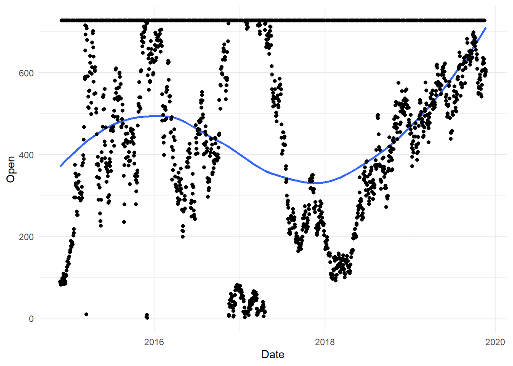

# DXY monthly average trend line.

```
##         DATE  avg_DXY
## 1 2014-11-01 214.4000
## 2 2014-12-01 201.9615
## 3 2015-01-01 309.1250
## 4 2015-02-01 380.5652
## 5 2015-03-01 574.5926
## 6 2015-04-01 604.6800
```

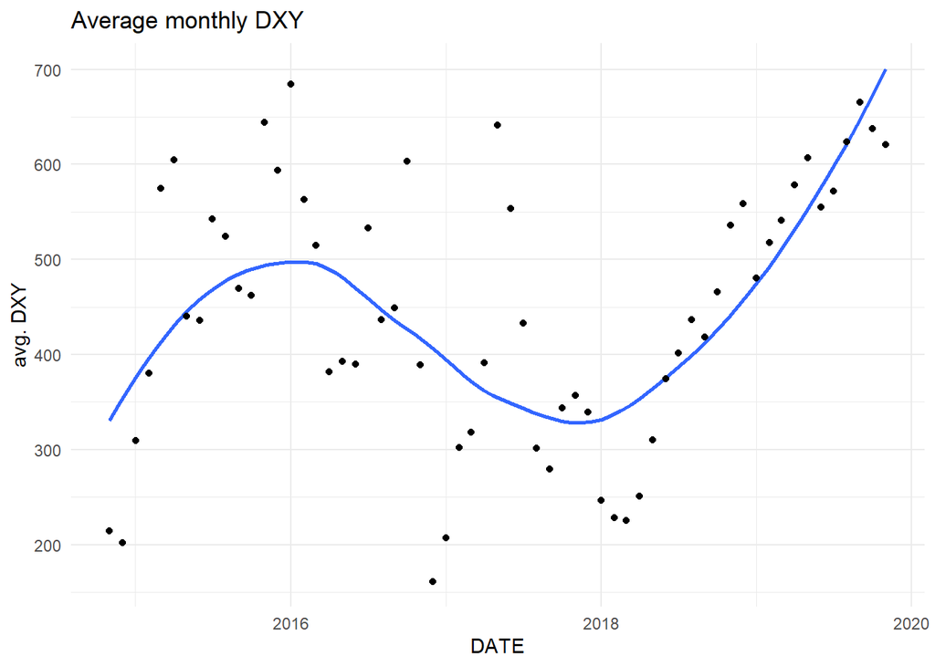

# Federal Fund Rate

```
##         DATE FEDFUNDS
## 1 2014-10-01     0.09
## 2 2014-11-01     0.09
## 3 2014-12-01     0.12
## 4 2015-01-01     0.11
## 5 2015-02-01     0.11
## 6 2015-03-01     0.11
```

```
## [1] 61
```

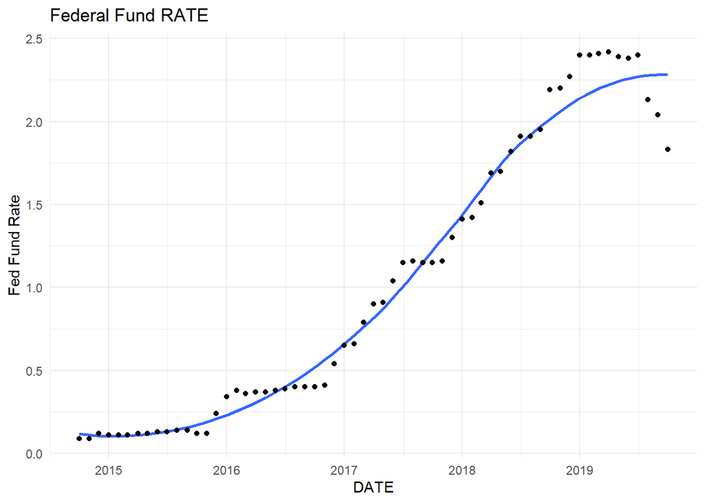

# Inflation Future Expected Rate

```
##         DATE T5YIFR
## 1 2014-11-24     88
## 2 2014-11-25     82
## 3 2014-11-26     79
## 4 2014-11-27      1
## 5 2014-11-28     78
## 6 2014-12-01     78
```

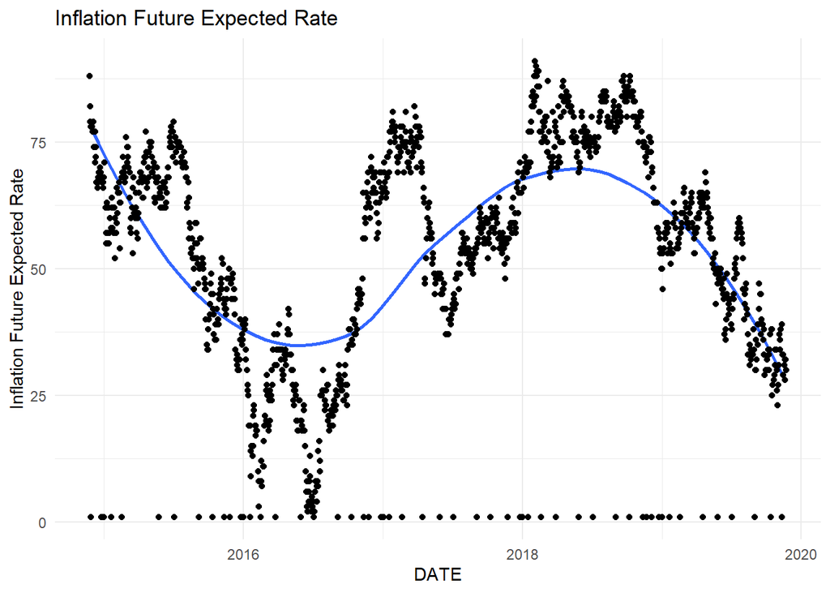

# Inflation Future Expected Rate monthly avg.rate

```
##         DATE  avg_Inf
## 1 2014-11-01 65.60000
## 2 2014-12-01 67.86957
## 3 2015-01-01 54.22727
## 4 2015-02-01 62.60000
## 5 2015-03-01 63.63636
## 6 2015-04-01 68.86364
```

```
## [1] 61
```

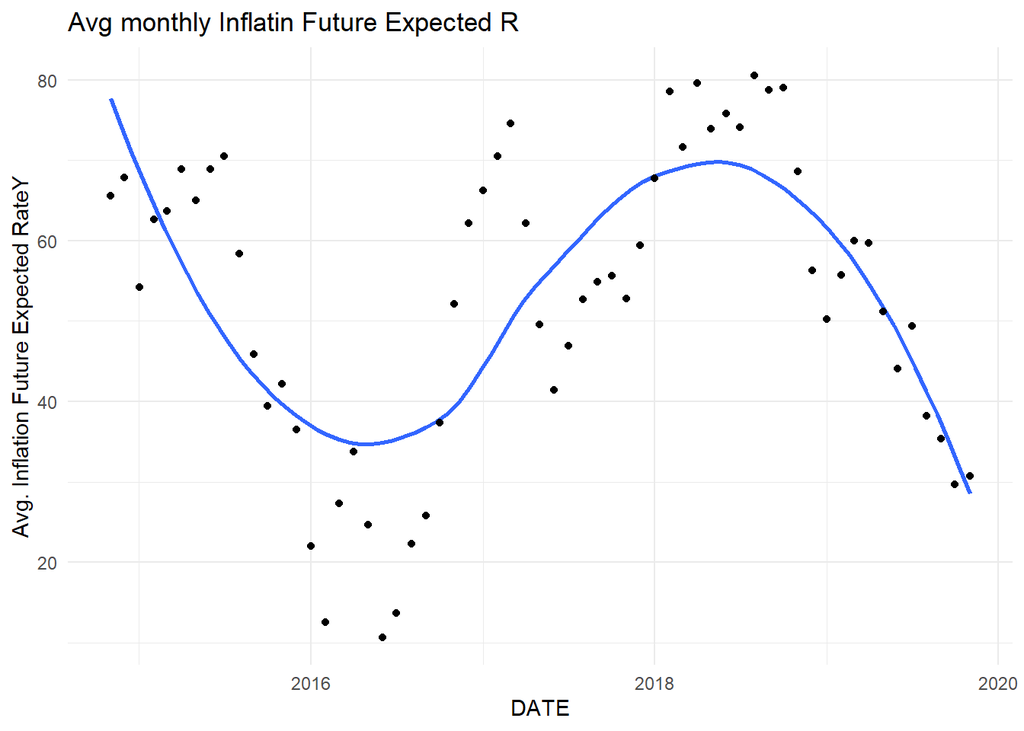

# Balance of Trades and Services payment

```
##          DATE BOPGSTB
## 1  2014-10-01  -40752
## 2  2014-11-01  -40087
## 3  2014-12-01  -43374
## 4  2015-01-01  -40785
## 5  2015-02-01  -35456
## 6  2015-03-01  -49502
## 7  2015-04-01  -41201
## 8  2015-05-01  -38643
## 9  2015-06-01  -42246
## 10 2015-07-01  -40810
```

```
## [1] 52
```

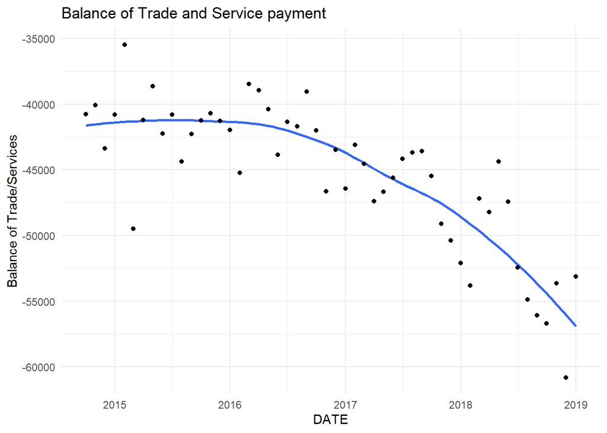

# GDP National Debt percentage

```
##         DATE GFDEGDQ188S
## 1 2014-04-01   101.14552
## 2 2014-07-01   100.57790
## 3 2014-10-01   101.63324
## 4 2015-01-01   100.93348
## 5 2015-04-01    99.63003
## 6 2015-07-01    98.94196
```

```
## [1] 21
```

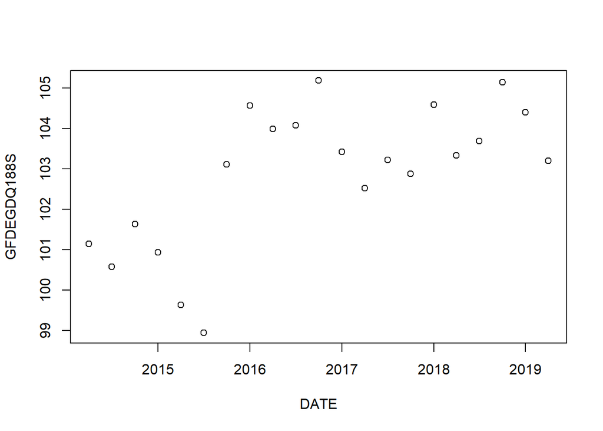

# Monthly Public debt to GDP % data frame based on its quarterly data frame.

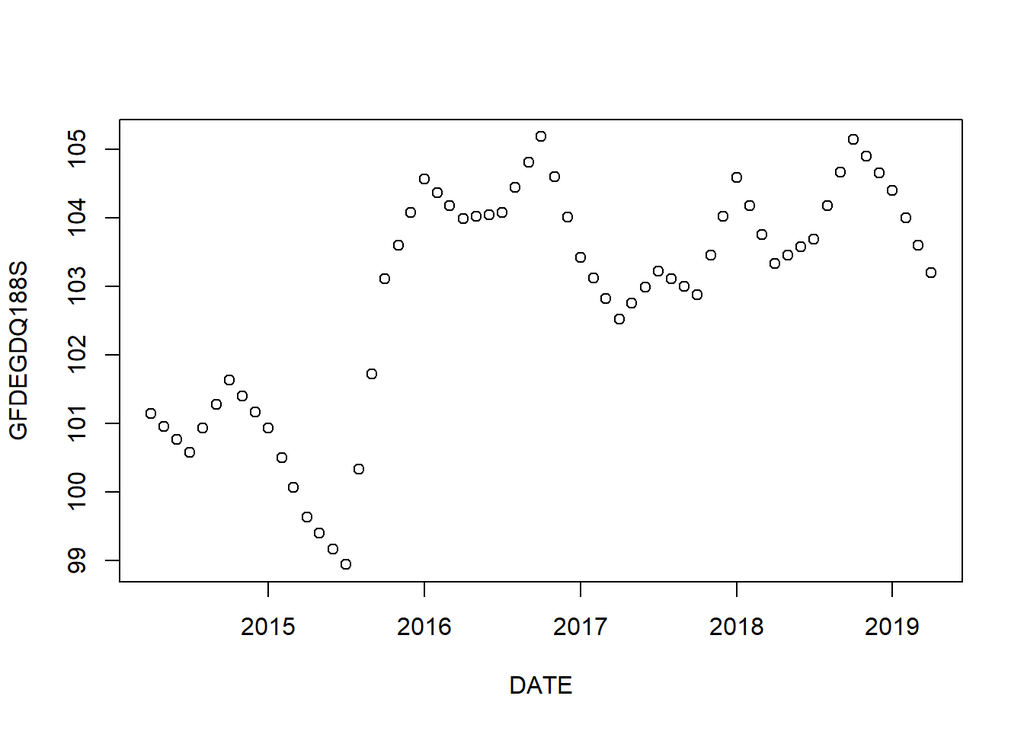

```
##         DATE GFDEGDQ188S
## 1 2014-04-01    101.1455
## 2 2014-05-01    100.9563
## 3 2014-06-01    100.7671
## 4 2014-07-01    100.5779
## 5 2014-08-01    100.9297
## 6 2014-09-01    101.2815
```

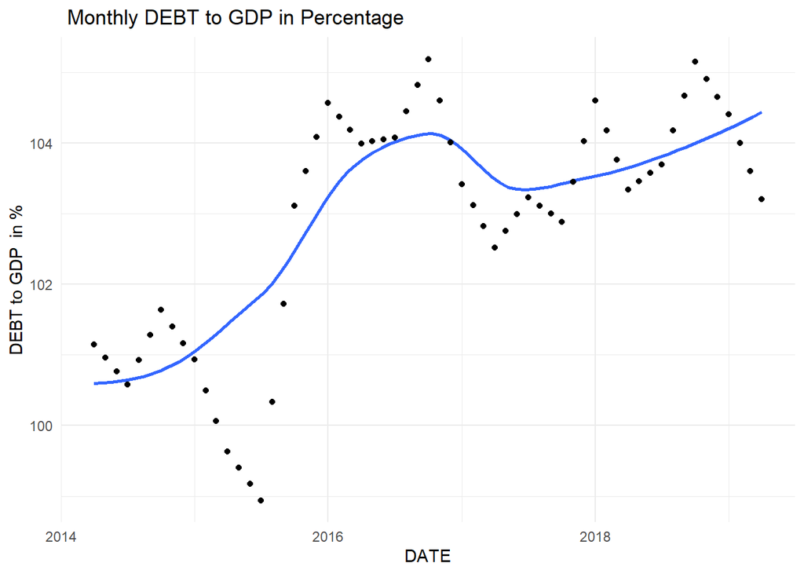

# DXY and economic indicators table

```
##          DATE  avg_DXY FEDFUNDS  avg_Inf BOPGSTB GFDEGDQ188S
## 1  2014-11-01 214.4000     0.09 65.60000  -40087   101.39999
## 2  2014-12-01 201.9615     0.12 67.86957  -43374   101.16673
## 3  2015-01-01 309.1250     0.11 54.22727  -40785   100.93348
## 4  2015-02-01 380.5652     0.11 62.60000  -35456   100.49900
## 5  2015-03-01 574.5926     0.11 63.63636  -49502   100.06451
## 6  2015-04-01 604.6800     0.12 68.86364  -41201    99.63003
## 7  2015-05-01 440.5200     0.12 64.95238  -38643    99.40067
## 8  2015-06-01 436.1538     0.13 68.90909  -42246    99.17132
## 9  2015-07-01 542.5385     0.13 70.47826  -40810    98.94196
## 10 2015-08-01 524.2308     0.14 58.33333  -44358   100.33248
## 11 2015-09-01 469.5600     0.14 45.90909  -42282   101.72299
## 12 2015-10-01 462.2308     0.12 39.45455  -41253   103.11351
## 13 2015-11-01 643.8800     0.12 42.14286  -40700   103.59659
## 14 2015-12-01 594.0385     0.24 36.52174  -41288   104.07968
## 15 2016-01-01 684.5600     0.34 22.04762  -41957   104.56276
## 16 2016-02-01 563.2400     0.38 12.52381  -45224   104.37311
## 17 2016-03-01 515.0000     0.36 27.26087  -38454   104.18347
## 18 2016-04-01 382.0800     0.37 33.76190  -38922   103.99382
## 19 2016-05-01 392.8077     0.37 24.68182  -40372   104.02146
## 20 2016-06-01 389.6538     0.38 10.68182  -43856   104.04910
```

```
## [1] 51
```

# Apply multiply Linear Regression.

## Predicted DXY = Bo+B1*Fed Fund rate =B2*Inflation Future Expected Rate +B3*Balance of Trade and Service payment +B4*Debt/GDP percentage +e

# Inflation and DEBT to GDP percentage p’s value indicate both indicators statistically significant. All these factors responsible for 27% variaiblity of the DXY price movement.

```
##
## Call:
## lm(formula = avg_DXY ~ FEDFUNDS + avg_Inf + BOPGSTB + GFDEGDQ188S,
##     data = Indicators)
##
## Residuals:
##     Min      1Q  Median      3Q     Max
## -213.87  -86.90    3.70   57.16  238.92
##
## Coefficients:
##               Estimate Std. Error t value Pr(>|t|)
## (Intercept)  4.163e+03  1.626e+03   2.560   0.0138 *
## FEDFUNDS     1.299e+01  4.898e+01   0.265   0.7920
## avg_Inf     -5.622e+00  1.305e+00  -4.307 8.59e-05 ***
## BOPGSTB     -1.132e-02  5.454e-03  -2.075   0.0436 *
## GFDEGDQ188S -3.845e+01  1.561e+01  -2.464   0.0176 *
## ---
## Signif. codes:  0 '***' 0.001 '**' 0.01 '*' 0.05 '.' 0.1 ' ' 1
##
## Residual standard error: 112.4 on 46 degrees of freedom
## Multiple R-squared:  0.3286, Adjusted R-squared:  0.2702
## F-statistic: 5.627 on 4 and 46 DF,  p-value: 0.0008985
```

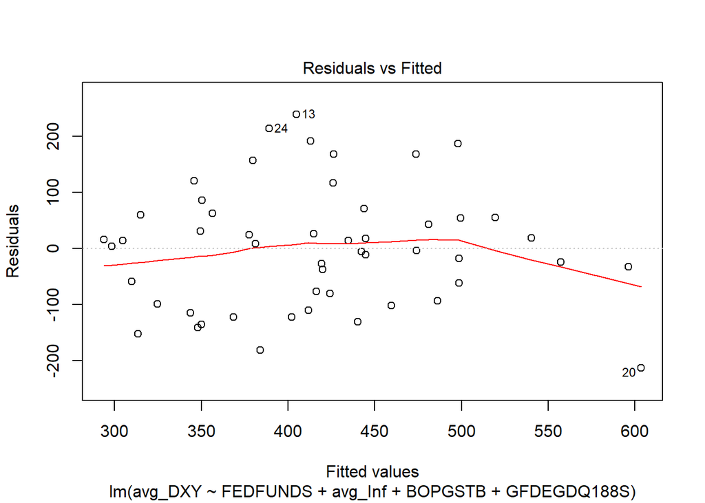

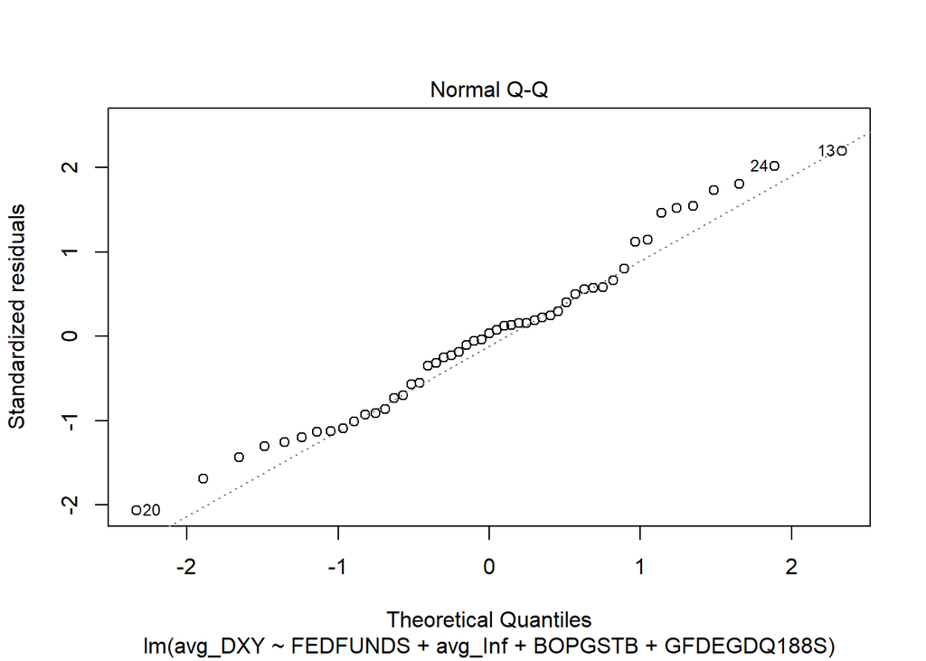

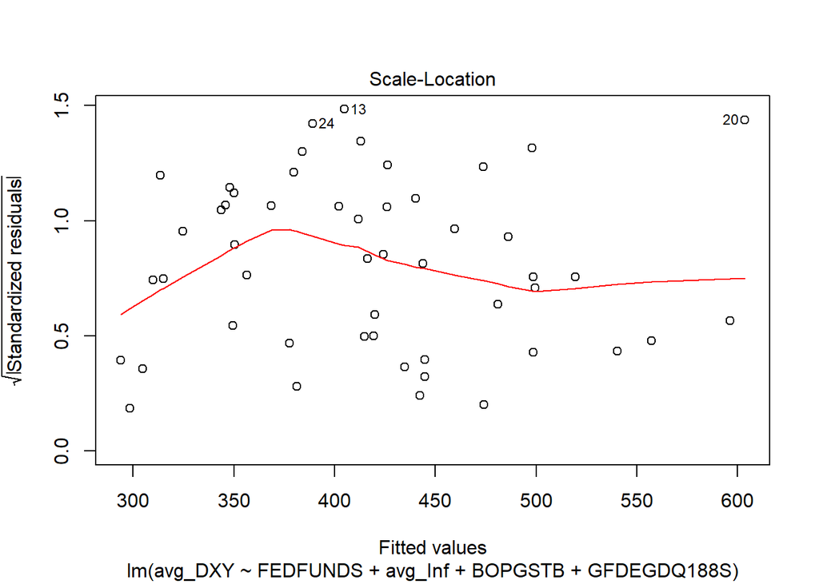

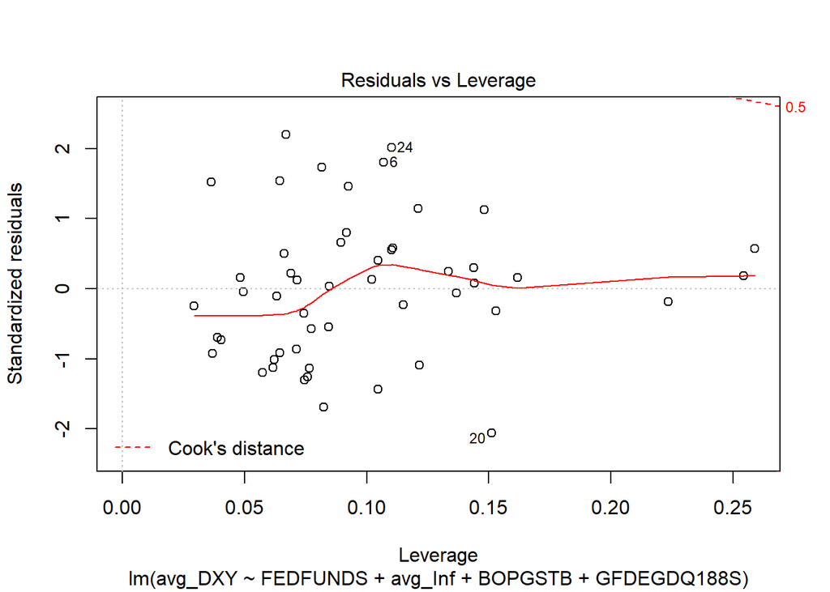

## Correlation: (DXY, Inf) Negatively correlated.

```
## [1] -0.434948
```

## Correlation: (DXY, Fed Fund) very slightly negatively correlated.

Because of the almost zero interest rate for the first few years, it skewed the distribution. The last few years indicated the closely positive correlation between DXY and Fed Fund.

```
## [1] -0.1634828
```

## Correlation:(DXY, Balance of Trade and Service Payments) Vey slight correlation.

```
## [1] 0.05533739
```

## Correlation:(DXY, Gov Debt/GDP percentage). Very slight correlation.

```
## [1] -0.01141755
```

## Expected DXY = B(0) + B(1) *Inflation Future Expected Rate + e

```
##
## Call:
## lm(formula = avg_DXY ~ avg_Inf, data = Indicators)
##
## Residuals:
##      Min       1Q   Median       3Q      Max
## -233.576  -94.588   -4.757   96.893  229.672
##
## Coefficients:
##             Estimate Std. Error t value Pr(>|t|)
## (Intercept) 578.1784    50.3505  11.483 1.68e-15 ***
## avg_Inf      -2.9503     0.8726  -3.381  0.00142 **
## ---
## Signif. codes:  0 '***' 0.001 '**' 0.01 '*' 0.05 '.' 0.1 ' ' 1
##
## Residual standard error: 119.7 on 49 degrees of freedom
## Multiple R-squared:  0.1892, Adjusted R-squared:  0.1726
## F-statistic: 11.43 on 1 and 49 DF,  p-value: 0.001425
```

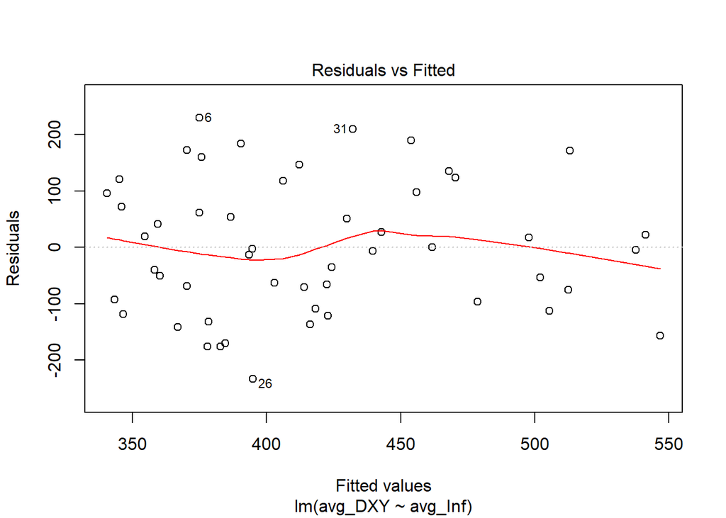

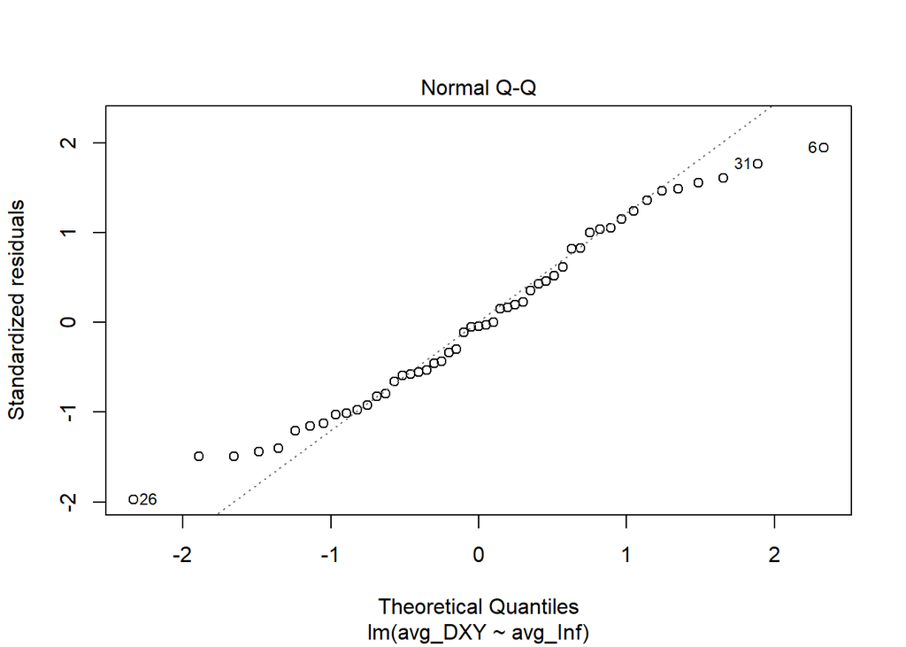

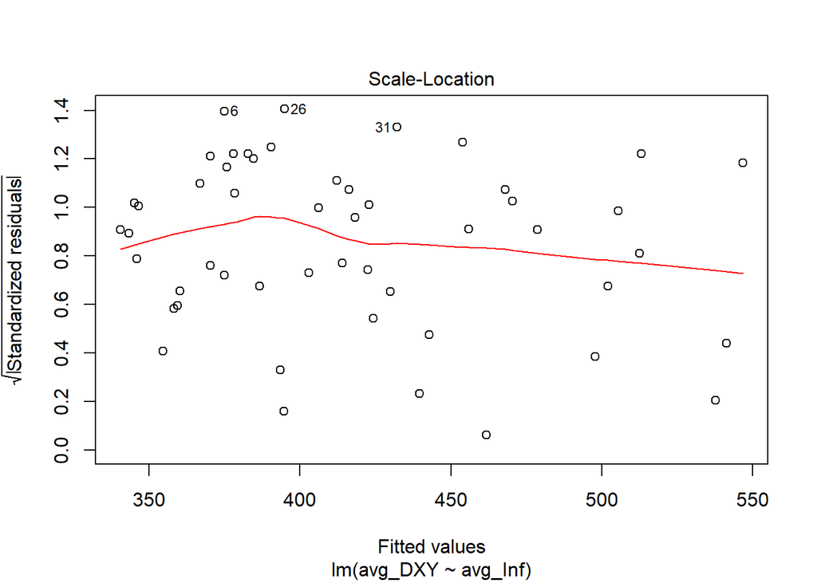

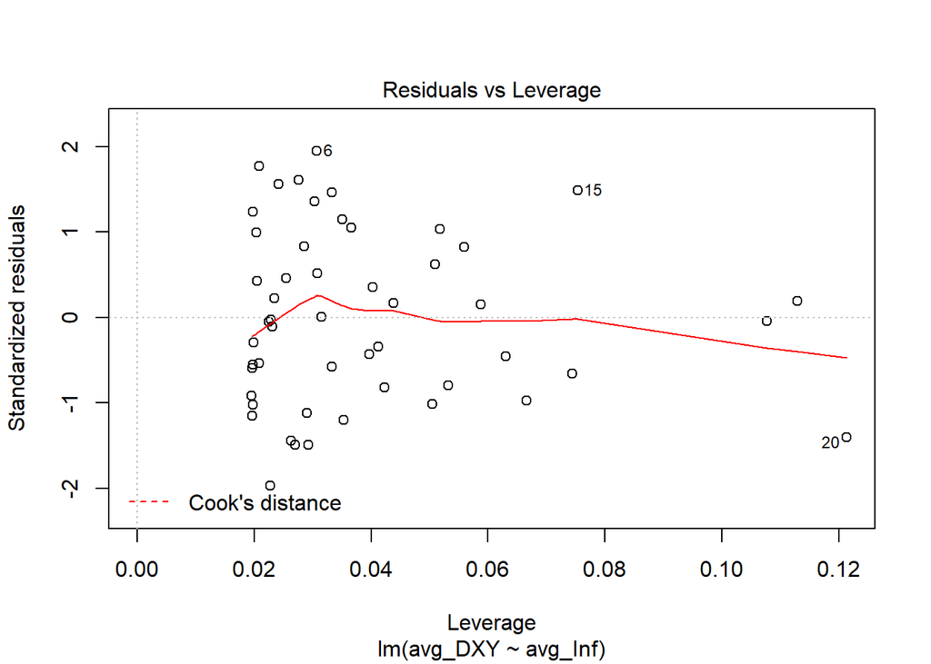

## Expected DXY = B(0) + B(1)* Fed Fund rate + e

```
##
## Call:
## lm(formula = avg_DXY ~ FEDFUNDS, data = Indicators)
##
## Residuals:
##      Min       1Q   Median       3Q      Max
## -265.442  -91.437    1.158  102.601  251.819
##
## Coefficients:
##             Estimate Std. Error t value Pr(>|t|)
## (Intercept)   442.97      28.53   15.53   <2e-16 ***
## FEDFUNDS      -30.09      25.94   -1.16    0.252
## ---
## Signif. codes:  0 '***' 0.001 '**' 0.01 '*' 0.05 '.' 0.1 ' ' 1
##
## Residual standard error: 131.1 on 49 degrees of freedom
## Multiple R-squared:  0.02673,    Adjusted R-squared:  0.006864
## F-statistic: 1.346 on 1 and 49 DF,  p-value: 0.2517
```

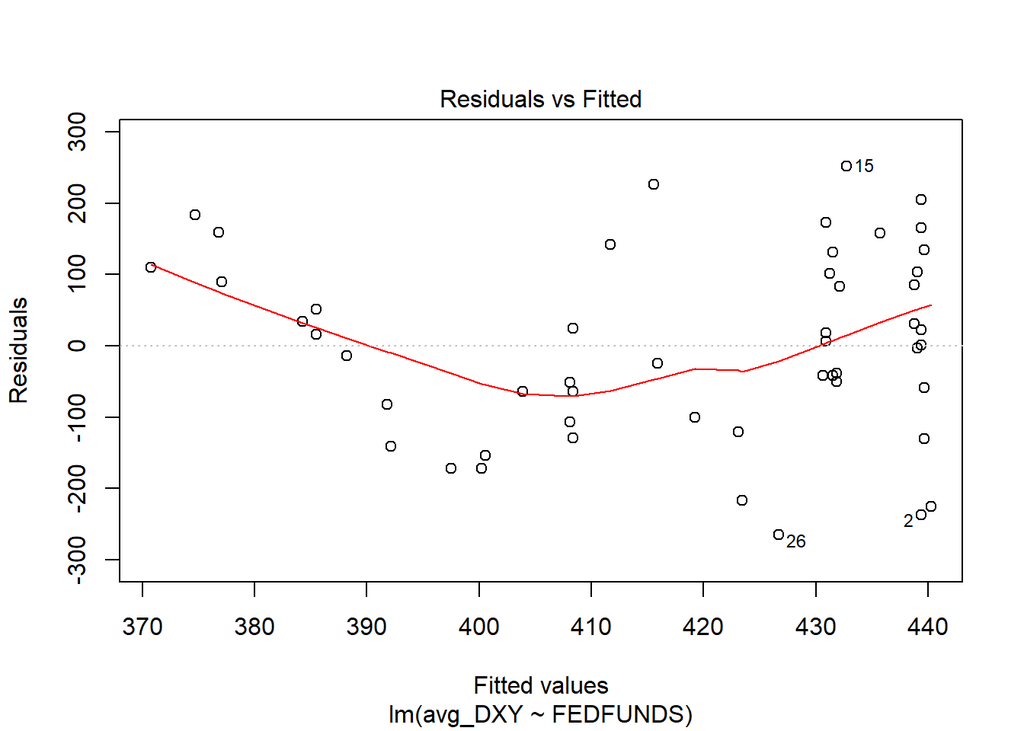

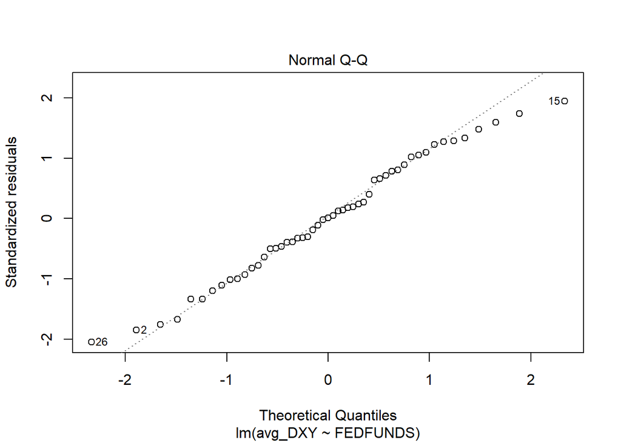

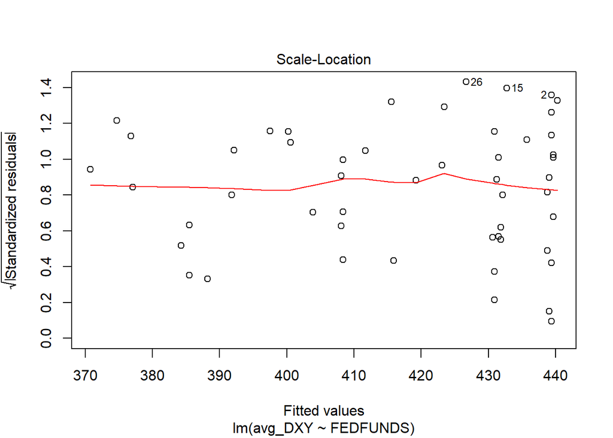

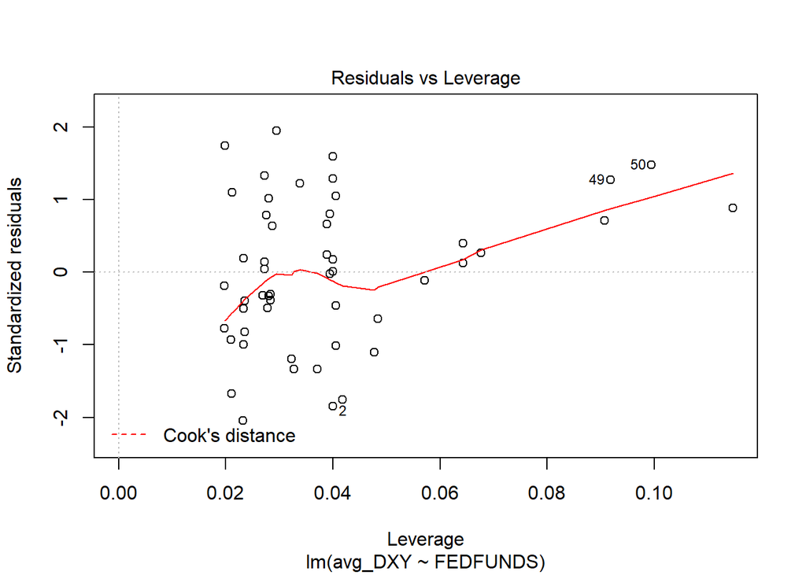

## The analysis

The movement of the DXY is in closely synch with the Inflation future rate albeit in the opposition direction. Therefore, the inflation future expected rate is good indicator to signal when and which direction the currency price will trend.

The inflation Future Expected rate pivoted but in an opposite direction at around the same time as the DXY. I suspect that the inflation rate I applied is not a past data but a future expected rate. That means the rate is calculated based on the past data to predict the movement of the inflation rate. The Federal Reserve predicts the future of the overall economy. It signals how the currency trend is going to be in the near future. The other indicators do not give a strong signal where the economic future heads to. The data is from the past.

# Conclusion: Inflation Future Expected Rate is the signal indicator

## 1. Economic factors influence the most on the valuation of the US dollars

```
    Ans:   Inflation Future Expected Rate.
```

## 2. Degree of influence these major economic factors have on the US dollars

[output not shown]

## 3. To determine how early the indicators signal a change in the US$ movement direction

```
    Ans:The Inflation Future Expected Rate is a future rate which based on huge number of economic data
    input to establish the rate. As a stock and FOREX investor, I will take advanage of this valuable data to            manage my investment portfolio. The other economic data trend does not have a consistent trend pattern with
    the DXY.
```